# 回归分析描述性统计

# 1 描述性统计

## 1.1 Settings

加载所有必要的包：

```r
library(ggplot2)
library(readxl)
library(patchwork)
library(tidyverse)
library(showtext)
```

图像设置：

```r
# 蓝色系调色板
job_palette <- c(
  "A" = "#4A90E2", # 深蓝 - 用于主要类别
  "B" = "#5DADE2", # 蓝色 - 用于次要类别
  "C" = "#85C1E9", # 浅蓝 - 用于第三级类别
  "D" = "#AED6F1", # 浅蓝 - 用于背景或次要信息
  "E" = "#D6EAF8" # 浅蓝白 - 用于补充信息
)

# 主题自定义函数
theme_job_analysis <- function() {
  theme_minimal() +
    theme(
      # 字体设置
      text = element_text(family = theme_font),

      # 标题设置
      plot.title = element_text(
        size = 16,
        face = "bold",
        hjust = 0.5,
        color = job_palette["A"],
        margin = margin(b = 20)
      ),

      # 副标题设置
      plot.subtitle = element_text(
        size = 12,
        hjust = 0.5,
        color = job_palette["B"],
        margin = margin(b = 10)
      ),

      # 轴标题设置
      axis.title = element_text(
        size = 12,
        color = job_palette["A"],
        margin = margin(t = 10, b = 10)
      ),

      # 轴文本设置
      axis.text = element_text(
        size = 10,
        color = "#666666"
      ),

      # 网格线设置
      panel.grid.major = element_line(
        color = "#EEEEEE",
        size = 0.2
      ),
      panel.grid.minor = element_blank(),

      # 图例设置
      legend.title = element_text(
        size = 11,
        color = job_palette["A"]
      ),
      legend.text = element_text(
        size = 10,
        color = "#666666"
      ),
      legend.position = "right",

      # 背景设置
      plot.background = element_rect(
        fill = "white",
        color = NA
      ),
      panel.background = element_rect(
        fill = "white",
        color = NA
      ),

      # 边距设置
      plot.margin = margin(t = 20, r = 20, b = 20, l = 20)
    )
}

# 全局字体设置
# theme_font <- "STSongti-SC-Black"
theme_font <- "SimHei"
# 启用中文字体支持
showtext_auto()
font_add(family = "SimHei", regular = "simhei.ttf")
```

## 1.2 数据读取与清理

### 1.2.1 读取数据

```r
data_raw <- read_excel("data.xlsx")
head(data_raw)
```

```
## # A tibble: 6 × 11
##   职位  位置    年薪 福利  已有工作经验 学历   公司行业        融资阶段 公司规模
##   <chr> <chr>  <dbl> <lgl> <chr>        <chr>  <chr>           <chr>    <chr>
## 1 CFO   广东   36    FALSE 5年以上      本科   服务业          未知     100-499
## 2 CFO   北京   45    FALSE 5年以上      本科   金融            未知     100-499
## 3 CFO   山东   24.6  FALSE 经验不限     研究生 互联网/IT/电子… 未融资   100以下
## 4 CFO   上海    8.25 TRUE  1-3年        本科   互联网/IT/电子… A轮      100以下
## 5 CFO   浙江  102    FALSE 5年以上      大专   金融            未知     100以下
## 6 CFO   上海  162.   TRUE  5年以上      研究生 互联网/IT/电子… C轮      100-499
## # ℹ 2 more variables: 职业类别 <chr>, log_salary <dbl>
```

### 1.2.2 数据清理

```r
# 统计每列缺失值
missing_summary <- colSums(is.na(data_raw))
print(missing_summary)
```

```
##         职位         位置         年薪         福利 已有工作经验         学历
##            0            0            0            0            0            0
##     公司行业     融资阶段     公司规模     职业类别   log_salary
##            0            0            0            0            0
```

```r
# 检查空值和空字符串的函数
check_empty <- function(data_raw) {
  # 创建一个空的结果向量
  empty_counts <- numeric(ncol(data_raw))
  names(empty_counts) <- names(data_raw)

  # 对每一列进行检查
  for (col in names(data_raw)) {
    # 统计 NA 或空字符串或只包含空格的情况
    empty_counts[col] <- sum(
      is.na(data_raw[[col]]) | # NA值
        data_raw[[col]] == "" | # 空字符串
        trimws(data_raw[[col]]) == "" | # 只包含空格的字符串
        is.null(data_raw[[col]]) # NULL值
    )
  }

  return(empty_counts)
}

# 使用函数检查
empty_summary <- check_empty(data_raw)
print(empty_summary)
```

```
##         职位         位置         年薪         福利 已有工作经验         学历
##            0            0            0            0            0            0
##     公司行业     融资阶段     公司规模     职业类别   log_salary
##            0            0            0            0            0
```

```r
# 统计包含任何空值的行数
rows_with_empty <- sum(apply(data_raw, 1, function(row) {
  any(is.na(row) | row == "" | trimws(row) == "" | is.null(row))
}))

# 输出统计信息
print(paste("总行数:", nrow(data_raw)))
```

```
## [1] "总行数: 9865"
```

```r
print(paste("包含空值的行数:", rows_with_empty))
```

```
## [1] "包含空值的行数: 0"
```

## 1.3 因变量描述性统计：年薪的处理

### 1.3.1 年薪箱线图、直方图统计

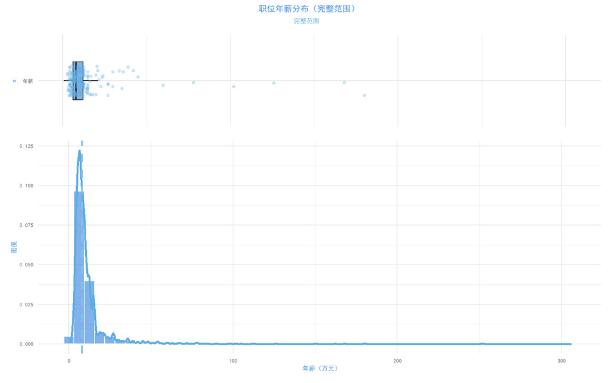

```r
# 创建基础箱线图函数，添加采样点参数
create_boxplot <- function(data_raw, y_limit = NULL) {
  ggplot(data_raw, aes(x = "年薪", y = 年薪)) +
    geom_boxplot(
      fill = job_palette["A"],
      alpha = 0.7,
      width = 0.5,
      outlier.shape = NA
    ) +
    geom_jitter(
      data = data_raw[sample(1:nrow(data_raw), min(nrow(data_raw) * 0.1, 200)), ],
      color = job_palette["B"],
      alpha = 0.3,
      width = 0.2,
      size = 1
    ) +
    labs(y = "年薪（万元）") +
    coord_flip() +
    theme_minimal() +
    theme(
      text = element_text(family = theme_font), # 默认中文字体
      axis.text = element_text(
        size = 10, color = "#666666", family = theme_font
      ), # 坐标轴刻度
      axis.title = element_text(size = 12, face = "bold", color = job_palette["A"], family = theme_font), # 坐标轴标题
      axis.text.x = element_blank(), # 隐藏 x 轴刻度
      axis.title.x = element_blank(), # 隐藏 x 轴标题
      axis.text.y = element_text(size = 10, family = theme_font), # y 轴刻度中文显示
      plot.title = element_text(size = 16, face = "bold", color = job_palette["A"], family = theme_font), # 图标题
      plot.subtitle = element_text(size = 12, color = job_palette["B"], family = theme_font) # 副标题
    ) +
    (if (!is.null(y_limit)) scale_y_continuous(limits = y_limit) else NULL)
}

# 创建直方图函数
create_histogram <- function(data_raw, x_limit = NULL) {
  ggplot(data_raw, aes(x = 年薪)) +
    geom_histogram(
      aes(y = ..density..),
      fill = job_palette["A"],
      color = "white",
      bins = 50,
      alpha = 0.7
    ) +
    geom_density(
      color = job_palette["B"],
      linewidth = 1
    ) +
    geom_vline(
      xintercept = median(data_raw$年薪, na.rm = TRUE),
      color = job_palette["C"],
      linetype = "dashed",
      linewidth = 1
    ) +
    labs(
      x = "年薪（万元）",
      y = "密度"
    ) +
    theme_minimal() +
    theme(
      text = element_text(family = theme_font), # 默认中文字体
      axis.text = element_text(size = 10, color = "#666666", family = theme_font), # 坐标轴刻度
      axis.title = element_text(size = 12, face = "bold", color = job_palette["A"], family = theme_font), # 坐标轴标题
      axis.text.x = element_text(size = 10, family = theme_font), # x 轴刻度中文显示
      axis.text.y = element_text(size = 10, family = theme_font), # y 轴刻度中文显示
      plot.title = element_text(size = 16, face = "bold", color = job_palette["A"], family = theme_font), # 图标题
      plot.subtitle = element_text(size = 12, color = job_palette["B"], family = theme_font) # 副标题
    ) +
    (if (!is.null(x_limit)) scale_x_continuous(limits = x_limit) else NULL)
}

# 计算统计量用于限定范围的图
salary_stats <- summary(data_raw$年薪)
salary_iqr <- IQR(data_raw$年薪, na.rm = TRUE)
salary_upper <- salary_stats[5] + 1.5 * salary_iqr
create_combined_plot <- function(data_raw, limits = NULL, title_suffix) {
  boxplot <- create_boxplot(data_raw, limits)
  histogram <- create_histogram(data_raw, limits)

  # 使用 patchwork 合并图形
  combined_plot <- boxplot + histogram +
    plot_layout(heights = c(0.3, 0.7)) +
    plot_annotation(
      title = paste0("职位年薪分布", title_suffix),
      subtitle = if (is.null(limits)) {
        "完整范围"
      } else {
        paste0("显示范围：0-", round(salary_upper, 1), "万元")
      },
      theme = theme(
        plot.title = element_text(
          size = 16,
          face = "bold",
          hjust = 0.5,
          color = job_palette["A"],
          family = theme_font
        ),
        plot.subtitle = element_text(
          size = 12,
          hjust = 0.5,
          color = job_palette["B"],
          family = theme_font
        )
      )
    )

  return(combined_plot)
}

# 生成两种图：完整范围和限定范围
combined_plot1 <- create_combined_plot(data_raw, NULL, "（完整范围）")
combined_plot2 <- create_combined_plot(data_raw, c(0, salary_upper), "（基本统计范围）")

# 显示图形
print(combined_plot1)
```

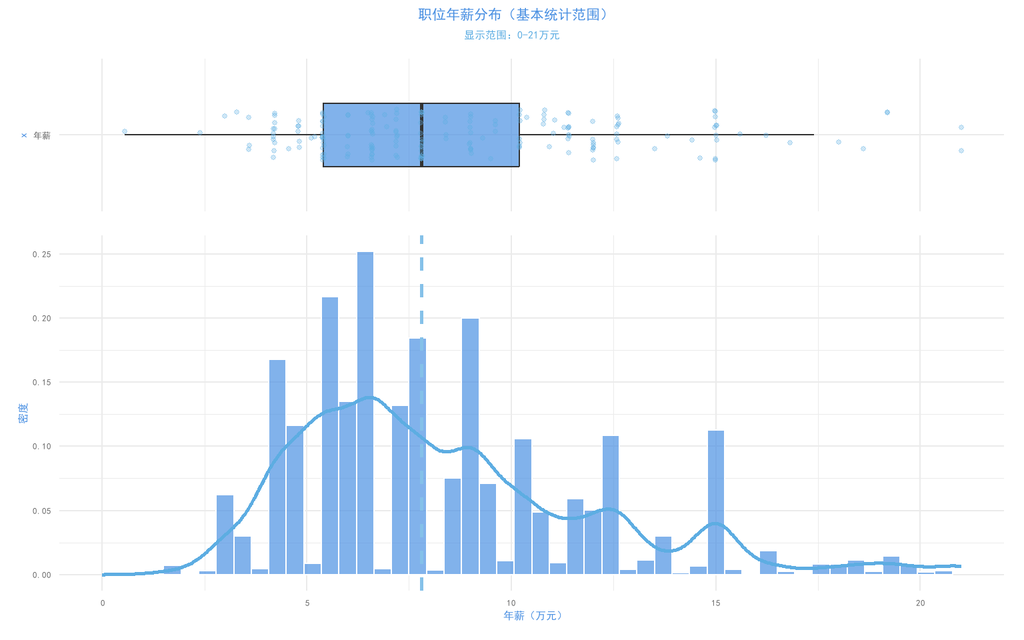

```r
print(combined_plot2)
```

图1：职位年薪分布（完整范围）

- 整体分布特征：该图展示了年薪的完整范围分布。大多数职位的年薪集中在较低区间，随着年薪的增大，职位数量迅速减少，形成了典型的右偏分布。年薪超过 200 万的职位较少，显示了较强的分布不均。
- 密度分布：从密度曲线可以看出，年薪的高峰值主要集中在较低的年薪区间（例如 10 万以下），密度随着年薪增大快速降低，说明绝大部分职位的年薪集中在低薪范围。

图2：职位年薪分布（基本统计范围）

总体分析

- 年薪分布具有显著的右偏特征，大多数职位集中在低年薪区间，高薪职位数量稀少且分布较为分散。
- 在基本统计范围内，年薪的分布较为集中，进一步说明了大部分职位具有较为集中的薪资结构。
- 综合来看，这种分布可能与行业特点、地区差异以及职位等级相关，值得进一步探讨各类影响因素对薪资分布的贡献。

```r
# 查看薪资的基本统计信息
summary(data_raw$年薪)
```

```
##     Min.  1st Qu.   Median     Mean  3rd Qu.     Max.
##   0.5475   6.0000   7.8000  11.2779  12.0000 306.0000
```

### 1.3.2 年薪对数化处理

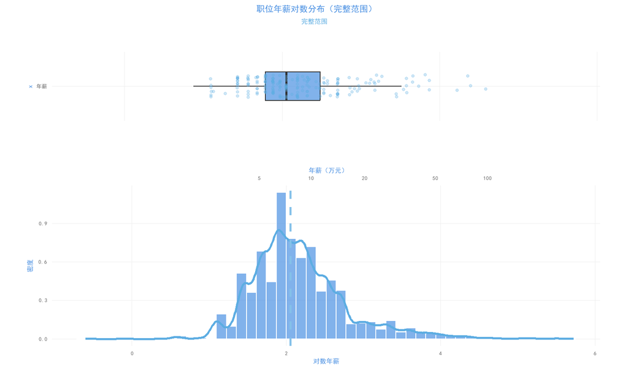

```r
# 创建对数年薪的箱线图函数
create_log_boxplot <- function(data, y_limit = NULL) {
  ggplot(data, aes(x = "年薪", y = log_salary)) +
    geom_boxplot(
      fill = job_palette["A"],
      alpha = 0.7,
      width = 0.5,
      outlier.shape = NA
    ) +
    geom_jitter(
      data = sample_n(data, min(nrow(data) * 0.1, 200)),
      color = job_palette["B"],
      alpha = 0.3,
      width = 0.2,
      size = 1
    ) +
    labs(y = "对数年薪") +
    coord_flip() +
    theme_job_analysis() +
    theme(
      axis.text.x = element_blank(),
      axis.title.x = element_blank()
    ) +
    (if (!is.null(y_limit)) scale_y_continuous(limits = y_limit) else NULL)
}

# 创建对数年薪的直方图函数
create_log_histogram <- function(data, x_limit = NULL) {
  ggplot(data, aes(x = log_salary)) +
    geom_histogram(
      aes(y = ..density..),
      fill = job_palette["A"],
      color = "white",
      bins = 50,
      alpha = 0.7
    ) +
    geom_density(
      color = job_palette["B"],
      linewidth = 1
    ) +
    geom_vline(
      xintercept = median(data$log_salary, na.rm = TRUE),
      color = job_palette["C"],
      linetype = "dashed",
      linewidth = 1
    ) +
    labs(
      x = "对数年薪",
      y = "密度"
    ) +
    theme_job_analysis() +
    (if (!is.null(x_limit)) scale_x_continuous(limits = x_limit) else NULL) +
    # 添加次坐标轴显示原始年薪值
    scale_x_continuous(
      sec.axis = sec_axis(
        trans = ~ exp(.),
        name = "年薪（万元）",
        breaks = c(5, 10, 20, 50, 100),
        labels = function(x) format(x, scientific = FALSE, big.mark = ",")
      )
    )
}

# 计算对数年薪的基本统计量
log_salary_stats <- summary(data_raw$log_salary)
log_salary_iqr <- IQR(data_raw$log_salary, na.rm = TRUE)
log_salary_upper <- log_salary_stats[5] + 1.5 * log_salary_iqr

# 创建对数年薪的组合图
create_log_combined_plot <- function(data, limits = NULL, title_suffix) {
  boxplot <- create_log_boxplot(data, limits)
  histogram <- create_log_histogram(data, limits)

  boxplot / histogram +
    plot_layout(heights = c(0.3, 0.7)) +
    plot_annotation(
      title = paste0("职位年薪对数分布", title_suffix),
      subtitle = if (is.null(limits)) {
        "完整范围"
      } else {
        "基本统计范围"
      },
      theme = theme(
        plot.title = element_text(
          size = 16,
          face = "bold",
          hjust = 0.5,
          color = job_palette["A"],
          family = theme_font
        ),
        plot.subtitle = element_text(
          size = 12,
          hjust = 0.5,
          color = job_palette["B"],
          family = theme_font
        )
      )
    )
}

# 生成两种对数图：完整范围和限定范围
log_combined_plot1 <- create_log_combined_plot(data_raw, NULL, "（完整范围）")
log_combined_plot2 <- create_log_combined_plot(data_raw, c(log(1), log_salary_upper), "（基本统计范围）")
# 显示图形
print(log_combined_plot1)
```

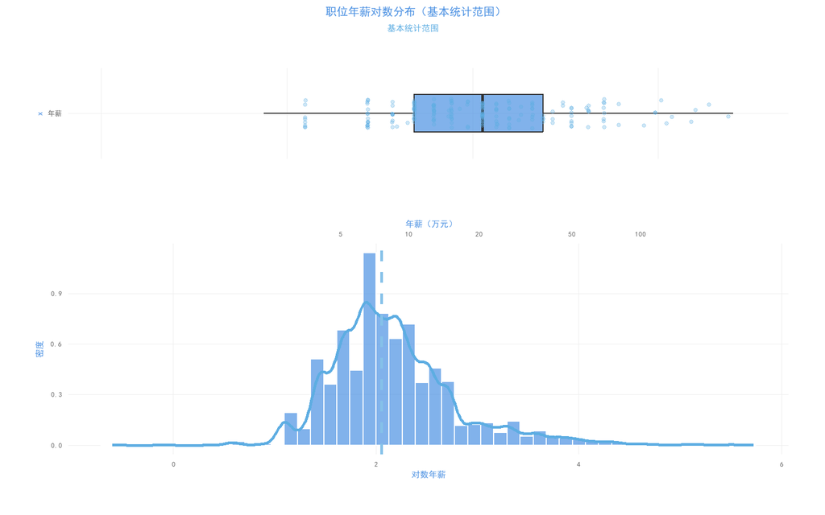

```r
print(log_combined_plot2)
```

在本次分析中，我们对年薪数据进行了对数变换，以改善模型的拟合效果，并从数据的分布和变量关系中获得更深刻的洞察。通过对数处理，年薪数据的分布显著优化，极大地减少了偏态和极端值的影响，使数据更接近正态分布。这一变换不仅有效降低了高薪职位对模型的偏倚影响，还缓解了回归分析中的异方差性问题，为模型假设的满足提供了更可靠的基础。

在结果解释上，对数变换后的模型输出可以更直观地理解为变量变化对薪资的比例影响，而非绝对值变化。这种比例解释符合实际场景的需求，为企业决策和政策制定提供了更有意义的参考依据。因此，对年薪数据的对数处理，不仅提高了分析的精确性，也提升了结果的实用价值和可解释性。

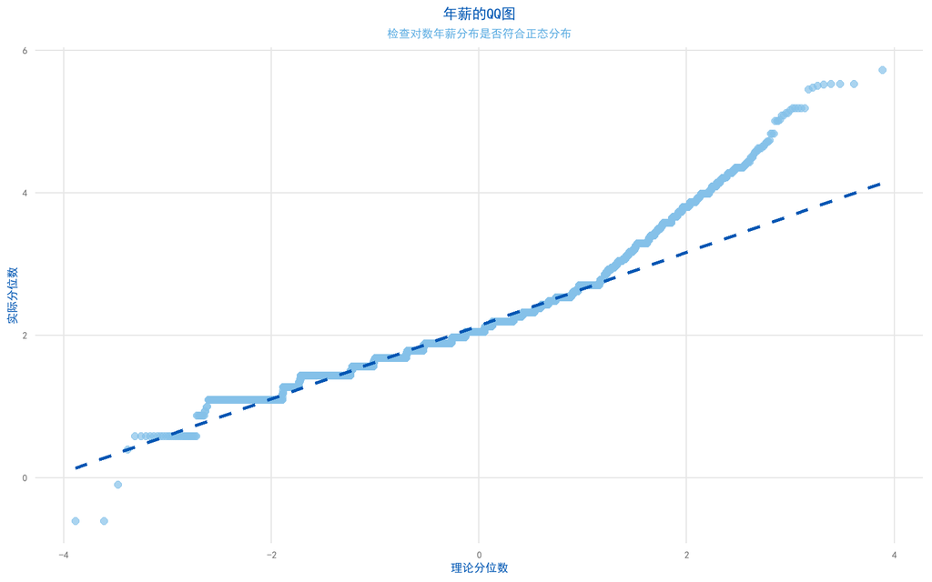

```r
# 绘制对数年薪的 QQ 图
p_qq <- ggplot(data_raw, aes(sample = log_salary)) +
  stat_qq(color = "#85C1E9", alpha = 0.7, size = 2) + # QQ 图点
  stat_qq_line(color = "#0056b3", linetype = "dashed", size = 1) + # QQ 图参考线
  labs(
    title = "年薪的QQ图",
    subtitle = "检查对数年薪分布是否符合正态分布",
    x = "理论分位数",
    y = "实际分位数"
  ) +
  theme_minimal() +
  theme(
    text = element_text(family = theme_font),
    plot.title = element_text(size = 18, hjust = 0.5, face = "bold", color = "#0056b3"),
    plot.subtitle = element_text(size = 14, hjust = 0.5, color = "#5DADE2"),
    axis.title.x = element_text(size = 14, face = "bold", color = "#0056b3"),
    axis.title.y = element_text(size = 14, face = "bold", color = "#0056b3"),
    axis.text.x = element_text(size = 12, color = "#666666"),
    axis.text.y = element_text(size = 12, color = "#666666"),
    panel.grid.major = element_line(color = "#E6E6E6"),
    panel.grid.minor = element_blank()
  )
print(p_qq)
```

```r
# 保存图像
# ggsave("log_salary_qqplot.png", plot = p_qq, height = 6, width = 6, dpi = 300)
```

总体而言，这张QQ图验证了对数变换的有效性，使得数据在大范围内更加接近正态分布，有助于提高模型假设的满足程度，为后续的回归分析和统计推断奠定了基础。

## 1.4 自变量描述性分析

### 1.4.1 统计基本描述性信息

```r
# 读取数据
data_log <- read.csv("data_log.csv", stringsAsFactors = FALSE)

# 简单数据预览
head(data_log)
```

```
##   X 职位 位置   年薪  福利 已有工作经验   学历            公司行业 融资阶段
## 1 1  CFO 广东  36.00 FALSE      5年以上   本科              服务业     未知
## 2 2  CFO 北京  45.00 FALSE      5年以上   本科                金融     未知
## 3 3  CFO 山东  24.60 FALSE     经验不限 研究生 互联网/IT/电子/通信   未融资
## 4 4  CFO 上海   8.25  TRUE        1-3年   本科 互联网/IT/电子/通信      A轮
## 5 5  CFO 浙江 102.00 FALSE      5年以上   大专                金融     未知
## 6 6  CFO 上海 162.50  TRUE      5年以上 研究生 互联网/IT/电子/通信      C轮
##   公司规模     职业类别 log_salary log_年薪
## 1  100-499 商务与管理类   3.583519 3.583519
## 2  100-499 商务与管理类   3.806662 3.806662
## 3  100以下 商务与管理类   3.202746 3.202746
## 4  100以下 商务与管理类   2.110213 2.110213
## 5  100以下 商务与管理类   4.624973 4.624973
## 6  100-499 商务与管理类   5.090678 5.090678
```

```r
str(data_log)
```

```
## 'data.frame':    9865 obs. of  13 variables:
##  $ X           : int  1 2 3 4 5 6 7 8 9 10 ...
##  $ 职位        : chr  "CFO" "CFO" "CFO" "CFO" ...
##  $ 位置        : chr  "广东" "北京" "山东" "上海" ...
##  $ 年薪        : num  36 45 24.6 8.25 102 ...
##  $ 福利        : logi  FALSE FALSE FALSE TRUE FALSE TRUE ...
##  $ 已有工作经验: chr  "5年以上" "5年以上" "经验不限" "1-3年" ...
##  $ 学历        : chr  "本科" "本科" "研究生" "本科" ...
##  $ 公司行业    : chr  "服务业" "金融" "互联网/IT/电子/通信" "互联网/IT/电子/通信" ...
##  $ 融资阶段    : chr  "未知" "未知" "未融资" "A轮" ...
##  $ 公司规模    : chr  "100-499" "100-499" "100以下" "100以下" ...
##  $ 职业类别    : chr  "商务与管理类" "商务与管理类" "商务与管理类" "商务与管理类" ...
##  $ log_salary  : num  3.58 3.81 3.2 2.11 4.62 ...
##  $ log_年薪    : num  3.58 3.81 3.2 2.11 4.62 ...
```

```r
# 统计基本描述性信息
summary(data_log)
```

```
##        X            职位               位置                年薪
##  Min.   :   1   Length:9865        Length:9865        Min.   :  0.5475
##  1st Qu.:2467   Class :character   Class :character   1st Qu.:  6.0000
##  Median :4933   Mode  :character   Mode  :character   Median :  7.8000
##  Mean   :4933                                         Mean   : 11.2779
##  3rd Qu.:7399                                         3rd Qu.: 12.0000
##  Max.   :9865                                         Max.   :306.0000
##     福利         已有工作经验           学历             公司行业
##  Mode :logical   Length:9865        Length:9865        Length:9865
##  FALSE:5885      Class :character   Class :character   Class :character
##  TRUE :3980      Mode  :character   Mode  :character   Mode  :character
##
##
##
##    融资阶段           公司规模           职业类别           log_salary
##  Length:9865        Length:9865        Length:9865        Min.   :-0.6024
##  Class :character   Class :character   Class :character   1st Qu.: 1.7918
##  Mode  :character   Mode  :character   Mode  :character   Median : 2.0541
##                                                           Mean   : 2.1651
##                                                           3rd Qu.: 2.4849
##                                                           Max.   : 5.7236
##     log_年薪
##  Min.   :-0.6024
##  1st Qu.: 1.7918
##  Median : 2.0541
##  Mean   : 2.1651
##  3rd Qu.: 2.4849
##  Max.   : 5.7236
```

根据数据集的基本描述性统计，我们可以得出以下结论：

1. 职位与样本量：数据集中共有 9865 个职位样本
2. 薪资分布：
   - 年薪的范围从 最低 0.55 万元 到 最高 306 万元，差异显著。
   - 年薪的中位数为 7.8 万元，平均值为 11.28 万元，说明部分高薪职位可能拉高了平均值。
   - 对数年薪的统计更直观，中位数为 2.05（对应约 7.8 万元），分布集中在 1.79 至 2.48 的范围（即约 6 万到 12 万之间）。
3. 福利分布：
   - 样本中，有 3980 个职位明确提供福利（占比约 40.3%），其余 5885 个职位未说明福利信息。
4. 工作经验：
   - 已有工作经验的字段覆盖了多种年限要求，从 经验不限 到 5 年以上不等，具体分布可进一步挖掘。
5. 学历与公司行业：
   - 数据中的学历字段涵盖了 “本科”、“研究生” 等多个层次，尚未归类。
   - 公司行业多样化，包括互联网、服务业、金融等多个领域，具体分布待进一步统计。
6. 公司规模与融资阶段：
   - 公司规模分布广泛，从 小于 100 人的小企业 到 500 人以上的大企业均有覆盖。
   - 融资阶段涵盖从 “未融资” 到 “D 轮及以上”，但也存在较多 “未知” 的条目。

### 1.4.2 x1=位置

```r
# 对城市等级统计职位数
city_level_summary <- data_log %>%
  group_by(位置) %>%
  summarise(
    职位数量 = n(),
    平均年薪 = mean(年薪, na.rm = TRUE),
    中位年薪 = median(年薪, na.rm = TRUE)
  ) %>%
  arrange(desc(职位数量))
print(city_level_summary)
```

```
## # A tibble: 34 × 4
##    位置  职位数量 平均年薪 中位年薪
##    <chr>    <int>    <dbl>    <dbl>
##  1 广东       946    10.2       7.8
##  2 山东       784     9.01      7.2
##  3 江苏       765    12.7       9
##  4 浙江       687    12.6       9.6
##  5 河北       473     7.84      7.2
##  6 北京       444    28.6      18
##  7 河南       440     8.26      6.6
##  8 四川       400     9.81      7.8
##  9 安徽       368     9.26      7.8
## 10 福建       359     9.68      7.8
## # ℹ 24 more rows
```

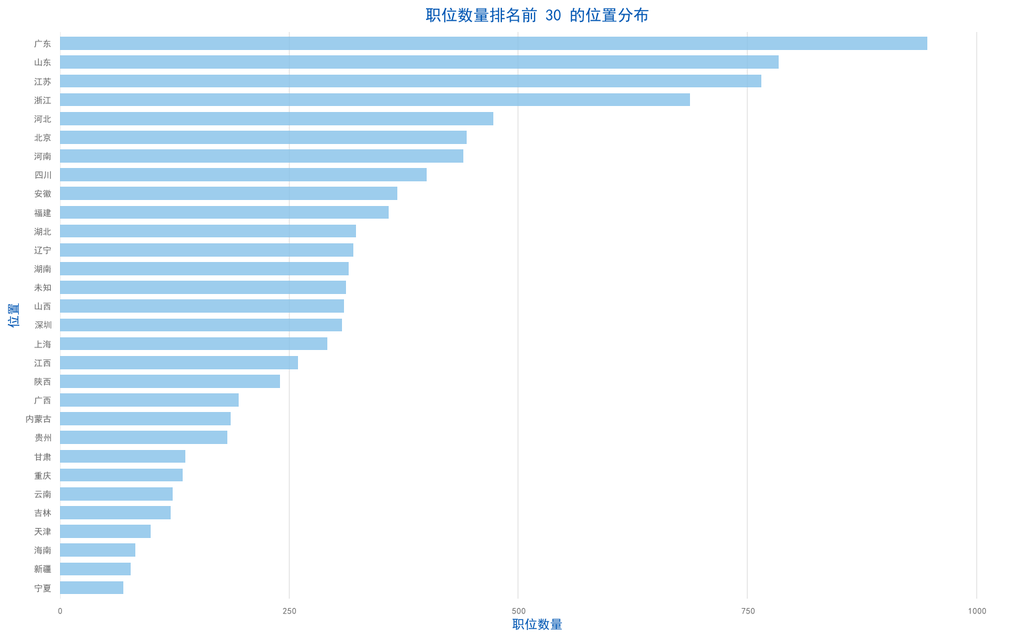

```r
# 只显示职位数量排名前30的城市
top_cities <- city_level_summary %>% slice_head(n = 30)

# 绘制优化后的柱状图
ggplot(top_cities, aes(x = reorder(位置, 职位数量), y = 职位数量)) +
  geom_bar(stat = "identity", fill = "#85C1E9", alpha = 0.8, width = 0.7) +
  coord_flip() +
  labs(
    title = "职位数量排名前 30 的位置分布",
    x = "位置",
    y = "职位数量"
  ) +
  theme_minimal() +
  theme(
    text = element_text(family = theme_font),
    plot.title = element_text(size = 18, hjust = 0.5, face = "bold", color = "#0056b3"),
    axis.title.x = element_text(size = 14, face = "bold", color = "#0056b3"),
    axis.title.y = element_text(size = 14, face = "bold", color = "#0056b3"),
    axis.text.x = element_text(size = 10, color = "#666666"), # 缩小字体大小
    axis.text.y = element_text(size = 10, color = "#666666"), # 缩小字体大小
    panel.grid.major.y = element_blank(), # 去掉网格线
    panel.grid.minor = element_blank() # 去掉次网格线
  ) +
  scale_y_continuous(expand = expansion(mult = c(0, 0.1))) # 为 y 轴添加额外空间
```

职位分布分析

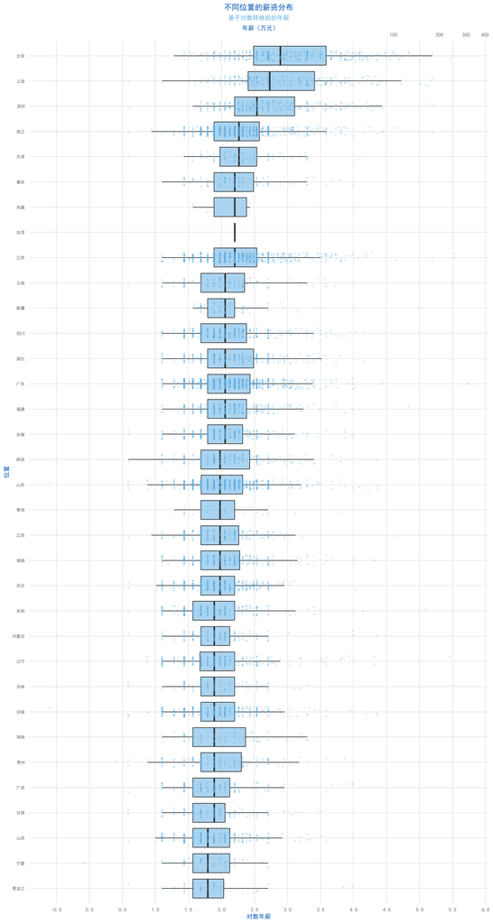

这种分布特征清晰反映了区域经济发展水平对薪资水平的影响以及职位分布的不均衡性。

### 1.4.3 x2=职位

```r
# 描述性统计
job_summary <- data_log %>%
  group_by(职位) %>%
  summarise(
    职位数量 = n(),
    平均年薪 = mean(年薪, na.rm = TRUE),
    中位年薪 = median(年薪, na.rm = TRUE)
  ) %>%
  arrange(desc(职位数量))

print(job_summary)
```

```
## # A tibble: 32 × 4
##    职位     职位数量 平均年薪 中位年薪
##    <chr>       <int>    <dbl>    <dbl>
##  1 顾问          908     9.44      7.8
##  2 工程师        773    13.4      10.8
##  3 电商运营      646     8.09      7.2
##  4 操作工人      582     6.65      6.6
##  5 设计          561     8.38      6.6
##  6 程序员        466    26.3      21.5
##  7 物流管理      384     8.36      8.4
##  8 工商管理      370     8.35      7.2
##  9 经理          366    13.5      10.2
## 10 会计          277     6.28      5.4
## # ℹ 22 more rows
```

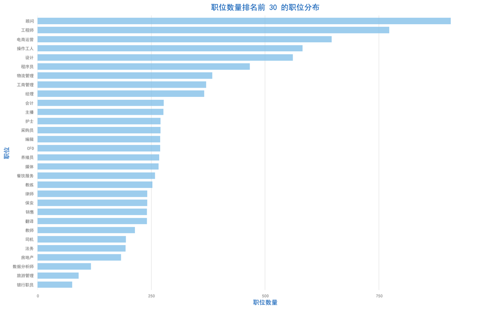

```r
# 对职位统计职位数
job_summary <- data_log %>%
  group_by(职位) %>%
  summarise(
    职位数量 = n(),
    平均年薪 = mean(年薪, na.rm = TRUE),
    中位年薪 = median(年薪, na.rm = TRUE)
  ) %>%
  arrange(desc(职位数量))

# 只显示职位数量排名前30的职位
top_jobs <- job_summary %>% slice_head(n = 30)

# 绘制职位数量排名前30的柱状图
ggplot(top_jobs, aes(x = reorder(职位, 职位数量), y = 职位数量)) +
  geom_bar(stat = "identity", fill = "#85C1E9", alpha = 0.8, width = 0.7) +
  coord_flip() +
  labs(
    title = "职位数量排名前 30 的职位分布",
    x = "职位",
    y = "职位数量"
  ) +
  theme_minimal() +
  theme(
    text = element_text(family = theme_font),
    plot.title = element_text(size = 18, hjust = 0.5, face = "bold", color = "#0056b3"),
    axis.title.x = element_text(size = 14, face = "bold", color = "#0056b3"),
    axis.title.y = element_text(size = 14, face = "bold", color = "#0056b3"),
    axis.text.x = element_text(size = 10, color = "#666666"),
    axis.text.y = element_text(size = 10, color = "#666666"),
    panel.grid.major.y = element_blank(),
    panel.grid.minor = element_blank()
  ) +
  scale_y_continuous(expand = expansion(mult = c(0, 0.1)))
```

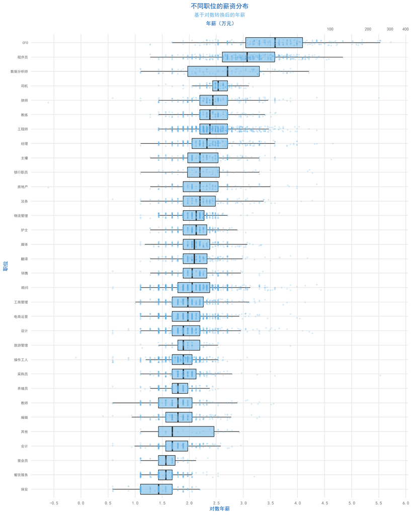

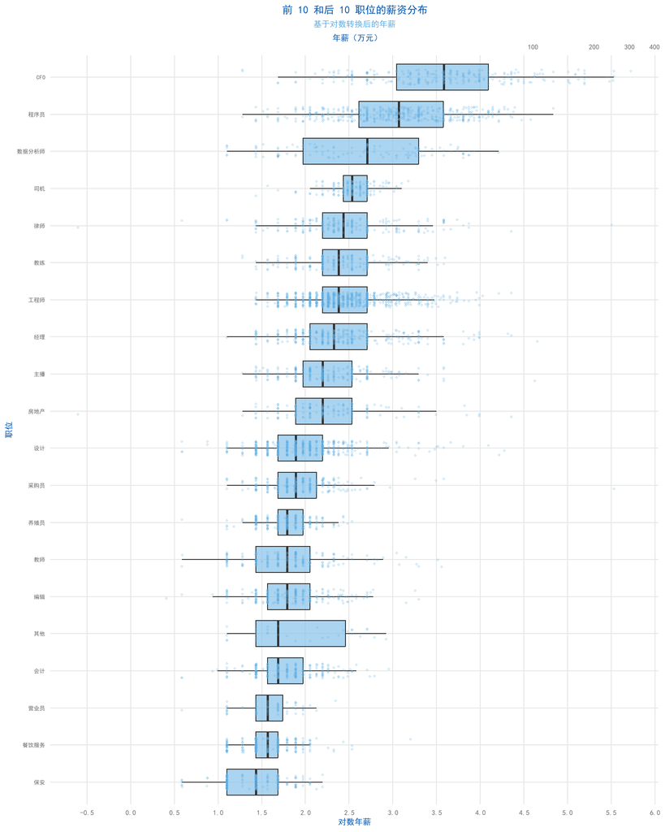

### 1.4.4 x3=福利

```r
# 描述性统计
work_experience_summary <- data_log %>%
  group_by(福利) %>%
  summarise(
    职位数量 = n(),
    平均年薪 = mean(年薪, na.rm = TRUE),
    中位年薪 = median(年薪, na.rm = TRUE)
  ) %>%
  arrange(desc(职位数量))
print(work_experience_summary)
```

```
## # A tibble: 2 × 4
##   福利  职位数量 平均年薪 中位年薪
##   <lgl>    <int>    <dbl>    <dbl>
## 1 FALSE     5885     9.30      7.2
## 2 TRUE      3980    14.2       9.6
```

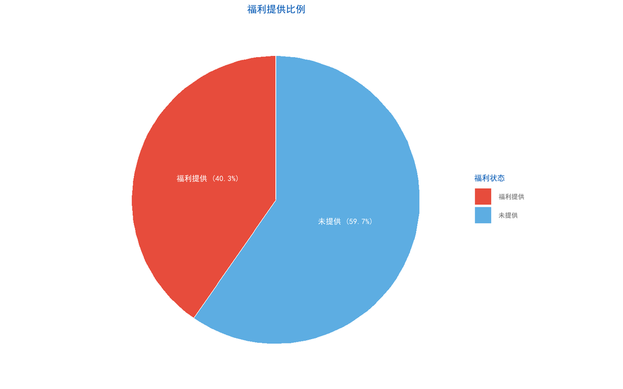

```r
# 对福利列进行统计
welfare_summary <- data_log %>%
  summarise(
    福利提供 = sum(福利 == TRUE, na.rm = TRUE),
    未提供 = sum(福利 == FALSE, na.rm = TRUE)
  ) %>%
  pivot_longer(cols = everything(), names_to = "福利状态", values_to = "数量") %>%
  mutate(
    比例 = 数量 / sum(数量),
    标签 = paste0(福利状态, " (", scales::percent(比例, accuracy = 0.1), ")")
  )

# 绘制饼图
p4 <- ggplot(welfare_summary, aes(x = "", y = 比例, fill = 福利状态)) +
  geom_bar(stat = "identity", width = 1, color = "white") +
  coord_polar("y", start = 0) +
  labs(
    title = "福利提供比例",
    fill = "福利状态"
  ) +
  theme_minimal() +
  theme(
    text = element_text(family = theme_font),
    plot.title = element_text(size = 18, hjust = 0.5, face = "bold", color = "#0056b3"),
    legend.title = element_text(size = 14, face = "bold", color = "#0056b3"),
    legend.text = element_text(size = 12, color = "#666666"),
    axis.text = element_blank(),
    axis.title = element_blank(),
    panel.grid = element_blank()
  ) +
  scale_fill_manual(values = c("#E74C3C", "#5DADE2")) + # 设置蓝色系配色
  geom_text(
    aes(label = 标签),
    position = position_stack(vjust = 0.5),
    family = theme_font,
    size = 5,
    color = "white"
  )

# 打印图形
print(p4)
```

```r
# 保存饼图
# ggsave("3_welfare_pie_chart.png", plot = p4, height = 6, width = 6, dpi = 300)
```

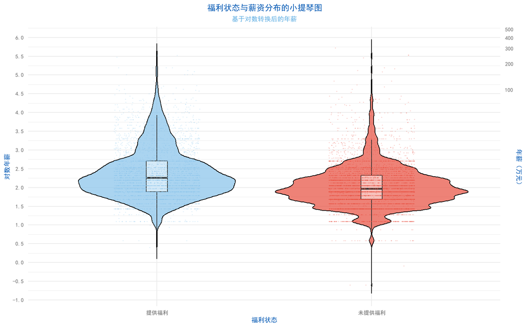

```r
# 创建福利状态列
data_log <- data_log %>%
  mutate(福利状态 = ifelse(福利, "提供福利", "未提供福利"))

# 绘制小提琴图
ggplot(data_log, aes(x = 福利状态, y = log_salary, fill = 福利状态)) +
  geom_violin(alpha = 0.7, color = "black", trim = FALSE) + # 小提琴图
  geom_boxplot(width = 0.1, fill = "white", alpha = 0.5, outlier.shape = NA) + # 添加嵌套箱线图
  geom_jitter(
    aes(color = 福利状态),
    alpha = 0.2,
    width = 0.2,
    size = 0.2
  ) + # 添加散点
  scale_fill_manual(values = c("提供福利" = "#85C1E9", "未提供福利" = "#E74C3C")) +
  scale_color_manual(values = c("提供福利" = "#85C1E9", "未提供福利" = "#E74C3C")) +
  labs(
    title = "福利状态与薪资分布的小提琴图",
    subtitle = "基于对数转换后的年薪",
    x = "福利状态",
    y = "对数年薪"
  ) +
  theme_minimal() +
  theme(
    text = element_text(family = theme_font),
    plot.title = element_text(size = 18, hjust = 0.5, face = "bold", color = "#0056b3"),
    plot.subtitle = element_text(size = 14, hjust = 0.5, color = "#5DADE2"),
    axis.title.x = element_text(size = 14, face = "bold", color = "#0056b3"),
    axis.title.y = element_text(size = 14, face = "bold", color = "#0056b3"),
    axis.text.x = element_text(size = 12, color = "#666666"),
    axis.text.y = element_text(size = 12, color = "#666666"),
    legend.position = "none"
  ) +
  scale_y_continuous(
    breaks = seq(floor(min(data_log$log_salary, na.rm = TRUE)),
      ceiling(max(data_log$log_salary, na.rm = TRUE)),
      by = 0.5
    ),
    labels = scales::number_format(accuracy = 0.1),
    sec.axis = sec_axis(
      trans = ~ exp(.),
      name = "年薪（万元）",
      labels = function(x) format(x, scientific = FALSE, big.mark = ",")
    )
  )
```

福利状态的图表分析结果如下：

1. 福利提供比例分析：
   - 从饼图中可以看出，未提供福利的职位占比为59.7%，超过一半的职位没有提供明确的福利。
2. 福利状态与薪资分布的小提琴图：
   - 从小提琴图可以观察到：
   - 提供福利的职位在薪资分布上呈现出较高的集中度和更长的高薪尾部，这表明提供福利的职位总体薪资水平更高。
   - 未提供福利的职位薪资分布相对集中于低薪范围，尾部的高薪占比较少，表明未提供福利的职位薪资水平普遍较低。
   - 小提琴图中箱线图部分进一步展示了两组职位的中位数和四分位间距的对比：提供福利的职位中位数明显高于未提供福利的职位。

### 1.4.5 x4=工作经验

```r
# 描述性统计
work_experience_summary <- data_log %>%
  group_by(已有工作经验) %>%
  summarise(
    职位数量 = n(),
    平均年薪 = mean(年薪, na.rm = TRUE),
    中位年薪 = median(年薪, na.rm = TRUE)
  ) %>%
  arrange(desc(职位数量))

print(work_experience_summary)
```

```
## # A tibble: 5 × 4
##   已有工作经验 职位数量 平均年薪 中位年薪
##   <chr>           <int>    <dbl>    <dbl>
## 1 经验不限         3862     8.76      7.2
## 2 1-3年            3000     9.48      7.8
## 3 3-5年            1491    14.8      10.8
## 4 1年以内           820     8.11      6.6
## 5 5年以上           692    29.3      16.2
```

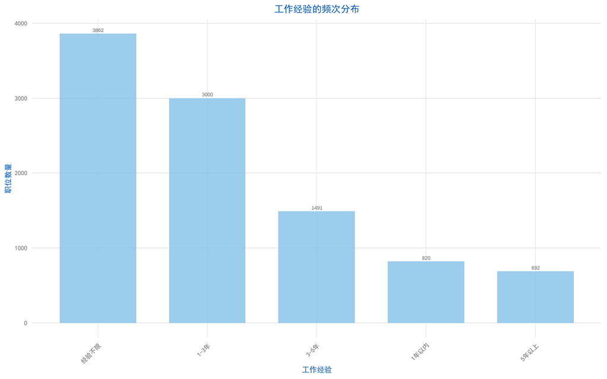

```r
# 绘制"工作经验"的频次分布图
p_frequency <- ggplot(work_experience_summary, aes(x = reorder(已有工作经验, -职位数量), y = 职位数量)) +
  geom_bar(stat = "identity", fill = "#85C1E9", alpha = 0.8, width = 0.7) +
  geom_text(aes(label = 职位数量), vjust = -0.5, size = 3.5, color = "#666666") +
  labs(
    title = "工作经验的频次分布",
    x = "工作经验",
    y = "职位数量"
  ) +
  theme_minimal() +
  theme(
    text = element_text(family = theme_font),
    plot.title = element_text(size = 18, hjust = 0.5, face = "bold", color = "#0056b3"),
    axis.title.x = element_text(size = 14, face = "bold", color = "#0056b3"),
    axis.title.y = element_text(size = 14, face = "bold", color = "#0056b3"),
    axis.text.x = element_text(size = 12, angle = 45, hjust = 1, color = "#666666"),
    axis.text.y = element_text(size = 12, color = "#666666"),
    panel.grid.major.y = element_line(color = "#E6E6E6"),
    panel.grid.minor = element_blank()
  )

print(p_frequency)
```

```r
# 保存频次分布图
# ggsave("work_experience_frequency.png", plot = p_frequency, height = 6, width = 8, dpi = 300)
```

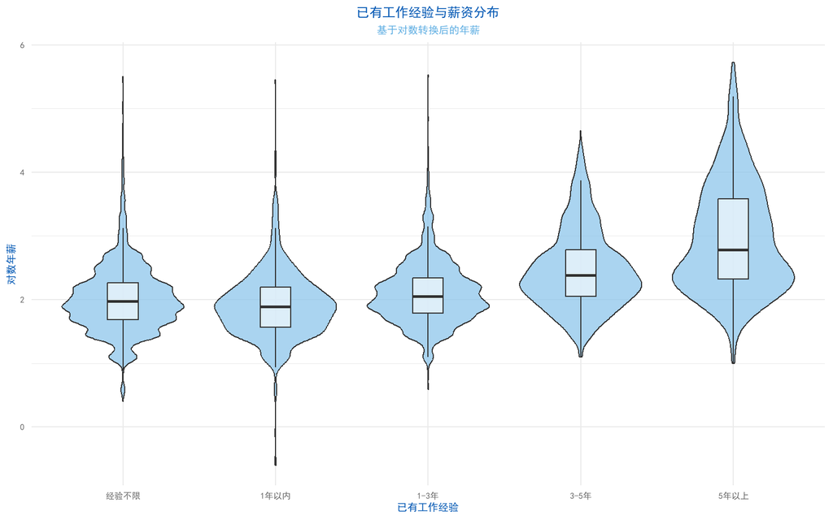

```r
# 绘制"已有工作经验"的小提琴图 + 箱线图
p_experience_salary <- ggplot(data_log, aes(x = factor(已有工作经验, levels = c("经验不限", "1年以内", "1-3年", "3-5年", "5年以上")), y = log(年薪))) +
  geom_violin(fill = "#85C1E9", alpha = 0.7, width = 0.8, scale = "width") + # 小提琴图
  geom_boxplot(width = 0.2, fill = "white", alpha = 0.6, outlier.shape = NA) + # 箱线图

  labs(
    title = "已有工作经验与薪资分布",
    subtitle = "基于对数转换后的年薪",
    x = "已有工作经验",
    y = "对数年薪"
  ) +
  theme_minimal() +
  theme(
    text = element_text(family = theme_font),
    plot.title = element_text(size = 18, hjust = 0.5, face = "bold", color = "#0056b3"),
    plot.subtitle = element_text(size = 14, hjust = 0.5, color = "#5DADE2"),
    axis.title.x = element_text(size = 14, face = "bold", color = "#0056b3"),
    axis.title.y = element_text(size = 14, face = "bold", color = "#0056b3"),
    axis.text.x = element_text(size = 12, angle = 0, hjust = 0.5, color = "#666666"),
    axis.text.y = element_text(size = 12, color = "#666666")
  )

print(p_experience_salary)
```

### 1.4.6 x5=学历

```r
# 描述性统计
xueli_summary <- data_log %>%
  group_by(学历) %>%
  summarise(
    职位数量 = n(),
    平均年薪 = mean(年薪, na.rm = TRUE),
    中位年薪 = median(年薪, na.rm = TRUE)
  ) %>%
  arrange(desc(职位数量))
print(xueli_summary)
```

```
## # A tibble: 5 × 4
##   学历       职位数量 平均年薪 中位年薪
##   <chr>         <int>    <dbl>    <dbl>
## 1 学历不限       3157     8.58      7.2
## 2 大专           2791     8.90      7.8
## 3 本科           2353    17.2      11.0
## 4 高中及以下     1357     7.38      6.6
## 5 研究生          207    42.3      33
```

[figure not shown]

```r
# 学历分布汇总并排序
education_summary <- data_log %>%
  group_by(学历) %>%
  summarise(
    count = n()
  ) %>%
  mutate(
    proportion = count / sum(count), # 计算比例
    学历 = factor(学历, levels = c("学历不限", "高中及以下", "大专", "本科", "研究生")) # 指定排序
  ) %>%
  arrange(学历) # 根据因子排序

# 绘制饼图
p_education_pie <- ggplot(education_summary, aes(x = "", y = proportion, fill = 学历)) +
  geom_bar(width = 1, stat = "identity", color = "white") +
  coord_polar(theta = "y") +
  labs(
    title = "学历分布比例",
    fill = "学历"
  ) +
  theme_void() +
  theme(
    text = element_text(family = theme_font),
    plot.title = element_text(size = 16, face = "bold", hjust = 0.5, color = "#0056b3"),
    legend.title = element_text(size = 12, face = "bold", color = "#0056b3"),
    legend.text = element_text(size = 10, color = "#666666")
  ) +
  scale_fill_manual(values = c("#85C1E9", "#5DADE2", "#4A90E2", "#2874A6", "#154360")) +
  geom_text(
    aes(
      label = paste0(round(proportion * 100, 1), "%"),
      y = cumsum(proportion) - proportion / 2 # 调整标注位置
    ),
    nudge_x = 0.8, # 将标注放在饼图外部
    family = theme_font,
    size = 4,
    color = "#154360" # 标注颜色
  )

# 打印饼图
print(p_education_pie)
```

```r
# 保存饼图
# ggsave("education_pie_no_guidelines.png", plot = p_education_pie, height = 6, width = 8, dpi = 300)
```

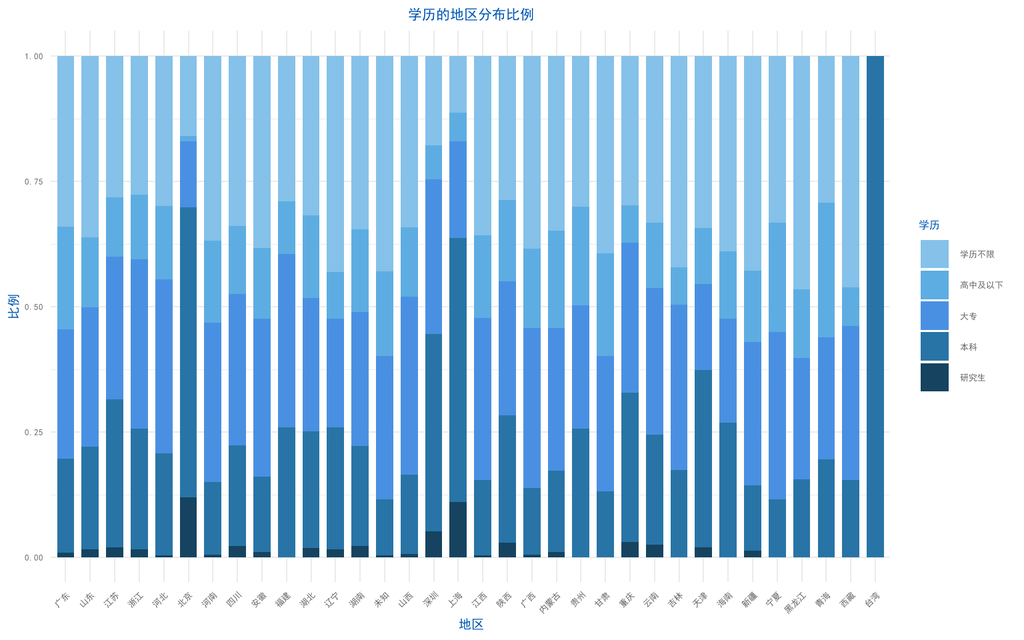

```r
# 学历的地区分布比例
education_region <- data_log %>%
  group_by(位置, 学历) %>%
  summarise(count = n(), .groups = "drop") %>%
  group_by(位置) %>%
  mutate(proportion = count / sum(count)) %>%
  ungroup()
education_levels <- c("学历不限", "高中及以下", "大专", "本科", "研究生")
education_region$学历 <- factor(education_region$学历, levels = education_levels)

# 计算各地区的总样本数，用于排序
region_order <- education_region %>%
  group_by(位置) %>%
  summarise(total_count = sum(count), .groups = "drop") %>%
  arrange(desc(total_count))

# 设置排序顺序
education_region$位置 <- factor(education_region$位置, levels = region_order$位置)

# 绘制堆叠比例柱状图
p_education_region <- ggplot(education_region, aes(x = 位置, y = proportion, fill = 学历)) +
  geom_bar(stat = "identity", position = "stack", width = 0.7) +
  labs(
    title = "学历的地区分布比例",
    x = "地区",
    y = "比例",
    fill = "学历"
  ) +
  theme_minimal() +
  theme(
    text = element_text(family = theme_font),
    plot.title = element_text(size = 16, face = "bold", hjust = 0.5, color = "#0056b3"),
    axis.title.x = element_text(size = 14, face = "bold", color = "#0056b3"),
    axis.title.y = element_text(size = 14, face = "bold", color = "#0056b3"),
    axis.text.x = element_text(size = 10, angle = 45, hjust = 1, color = "#666666"),
    axis.text.y = element_text(size = 10, color = "#666666"),
    legend.title = element_text(size = 12, face = "bold", color = "#0056b3"),
    legend.text = element_text(size = 10, color = "#666666")
  ) +
  scale_fill_manual(
    values = c(
      "学历不限" = "#85C1E9",
      "高中及以下" = "#5DADE2",
      "大专" = "#4A90E2",
      "本科" = "#2874A6",
      "研究生" = "#154360"
    )
  )

# 打印图像
print(p_education_region)
```

```r
# 保存图像
# ggsave("education_region_distribution.png", plot = p_education_region, height = 8, width = 12, dpi = 300)
```

学历分布比例

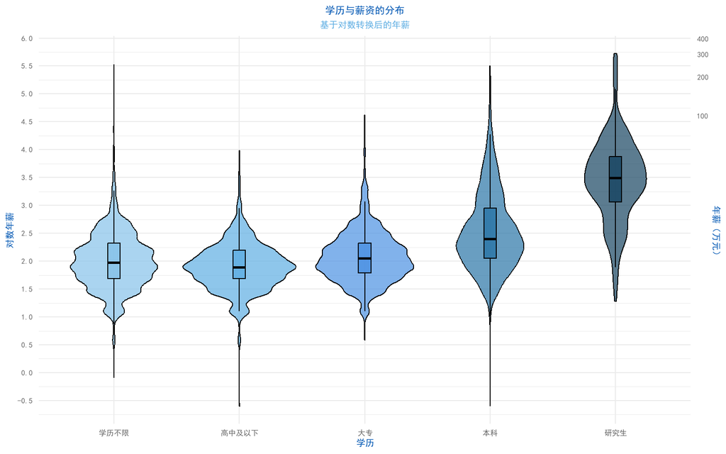

```r
# 确保学历按照固定顺序排列
education_levels <- c("学历不限", "高中及以下", "大专", "本科", "研究生")
data_log$学历 <- factor(data_log$学历, levels = education_levels)

# 绘制学历与对数年薪的联合图（小提琴图 + 箱线图）
p_education_salary <- ggplot(data_log, aes(x = 学历, y = log_salary, fill = 学历)) +
  geom_violin(trim = TRUE, alpha = 0.7, color = "black") + # 小提琴图
  geom_boxplot(width = 0.1, color = "black", outlier.shape = NA, alpha = 0.8) + # 箱线图

  labs(
    title = "学历与薪资的分布",
    subtitle = "基于对数转换后的年薪",
    x = "学历",
    y = "对数年薪"
  ) +
  theme_minimal() +
  theme(
    text = element_text(family = theme_font),
    plot.title = element_text(size = 16, face = "bold", hjust = 0.5, color = "#0056b3"),
    plot.subtitle = element_text(size = 14, hjust = 0.5, color = "#5DADE2"),
    axis.title.x = element_text(size = 14, face = "bold", color = "#0056b3"),
    axis.title.y = element_text(size = 14, face = "bold", color = "#0056b3"),
    axis.text.x = element_text(size = 12, color = "#666666"),
    axis.text.y = element_text(size = 12, color = "#666666"),
    legend.position = "none" # 去掉图例
  ) +
  scale_fill_manual(
    values = c(
      "学历不限" = "#85C1E9",
      "高中及以下" = "#5DADE2",
      "大专" = "#4A90E2",
      "本科" = "#2874A6",
      "研究生" = "#154360"
    )
  ) +
  scale_y_continuous(
    breaks = seq(floor(min(data_log$log_salary, na.rm = TRUE)),
      ceiling(max(data_log$log_salary, na.rm = TRUE)),
      by = 0.5
    ),
    labels = scales::number_format(accuracy = 0.1),
    sec.axis = sec_axis(
      trans = ~ exp(.),
      name = "年薪（万元）",
      labels = function(x) format(x, scientific = FALSE, big.mark = ",")
    )
  )

# 打印图像
print(p_education_salary)
```

```r
# 保存图像
# ggsave("education_salary_violin.png", plot = p_education_salary, height = 8, width = 12, dpi = 300)
```

学历与薪资的分布

### 1.4.7 x6=公司行业

```r
# 描述性统计
industry_summary <- data_log %>%
  group_by(公司行业) %>%
  summarise(
    职位数量 = n(),
    平均年薪 = mean(年薪, na.rm = TRUE),
    中位年薪 = median(年薪, na.rm = TRUE)
  ) %>%
  arrange(desc(职位数量))

print(industry_summary)
```

```
## # A tibble: 14 × 4
##    公司行业             职位数量 平均年薪 中位年薪
##    <chr>                   <int>    <dbl>    <dbl>
##  1 互联网/IT/电子/通信      2495    15.4       9
##  2 房地产/建筑              1096     9.31      7.8
##  3 交通/物流/贸易/零售       999     9.28      7.8
##  4 服务业                    880     7.36      6
##  5 广告/传媒/文化/体育       817     9.91      7.8
##  6 专业服务                  575    12.5       9
##  7 机械/制造                 468    11.2       8.1
##  8 教育培训                  421     8.63      6.6
##  9 制药/医疗                 415     9.79      7.8
## 10 汽车                      415    10.3       7.8
## 11 消费品                    389    10.0       7.2
## 12 政府/非盈利机构/其他      362     8.50      6.6
## 13 金融                      287    15.4      10.8
## 14 能源/化工/环保            246    12.6       9
```

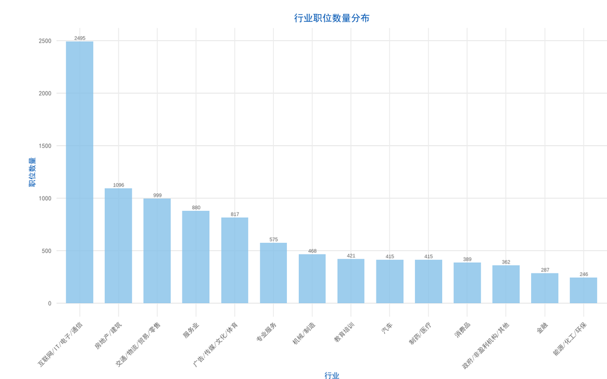

```r
# 绘制"行业"的职位数量分布柱状图
p_industry_frequency <- ggplot(industry_summary, aes(x = reorder(公司行业, -职位数量), y = 职位数量)) +
  geom_bar(stat = "identity", fill = "#85C1E9", alpha = 0.8, width = 0.7) +
  geom_text(aes(label = 职位数量), vjust = -0.5, size = 3.5, color = "#666666") +
  labs(
    title = "行业职位数量分布",
    x = "行业",
    y = "职位数量"
  ) +
  theme_minimal() +
  theme(
    text = element_text(family = theme_font),
    plot.title = element_text(size = 18, hjust = 0.5, face = "bold", color = "#0056b3"),
    axis.title.x = element_text(size = 14, face = "bold", color = "#0056b3"),
    axis.title.y = element_text(size = 14, face = "bold", color = "#0056b3"),
    axis.text.x = element_text(size = 12, angle = 45, hjust = 1, color = "#666666"),
    axis.text.y = element_text(size = 12, color = "#666666"),
    panel.grid.major.y = element_line(color = "#E6E6E6"),
    panel.grid.minor = element_blank(),
    plot.margin = unit(c(0.5, 0, 0, 1), "cm") # 增加上下左右边距
  )

print(p_industry_frequency)
```

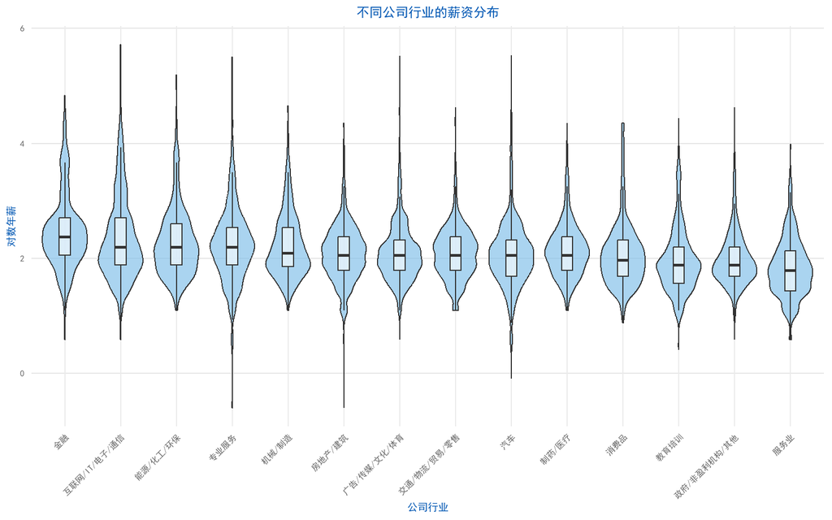

```r
# 小提琴图 + 箱线图（公司行业）
p_industry_combined <- ggplot(data_log, aes(x = reorder(公司行业, -log_salary, FUN = median), y = log_salary)) +
  geom_violin(fill = "#85C1E9", alpha = 0.7, width = 0.8, scale = "width") + # 小提琴图
  geom_boxplot(width = 0.2, fill = "white", alpha = 0.6, outlier.shape = NA) + # 箱线图
  labs(
    title = "不同公司行业的薪资分布",
    x = "公司行业",
    y = "对数年薪"
  ) +
  theme_minimal() +
  theme(
    text = element_text(family = theme_font),
    plot.title = element_text(size = 18, hjust = 0.5, face = "bold", color = "#0056b3"),
    axis.title.x = element_text(size = 14, face = "bold", color = "#0056b3"),
    axis.title.y = element_text(size = 14, face = "bold", color = "#0056b3"),
    axis.text.x = element_text(size = 12, angle = 45, hjust = 1, color = "#666666"),
    axis.text.y = element_text(size = 12, color = "#666666"),
    panel.grid.major.y = element_line(color = "#E6E6E6"),
    panel.grid.minor = element_blank()
  )

print(p_industry_combined)
```

### 1.4.8 x7=融资阶段

```r
# 描述性统计
finance_summary <- data_log %>%
  group_by(公司行业) %>%
  summarise(
    职位数量 = n(),
    平均年薪 = mean(年薪, na.rm = TRUE),
    中位年薪 = median(年薪, na.rm = TRUE)
  ) %>%
  arrange(desc(职位数量))

print(finance_summary)
```

```
## # A tibble: 14 × 4
##    公司行业             职位数量 平均年薪 中位年薪
##    <chr>                   <int>    <dbl>    <dbl>
##  1 互联网/IT/电子/通信      2495    15.4       9
##  2 房地产/建筑              1096     9.31      7.8
##  3 交通/物流/贸易/零售       999     9.28      7.8
##  4 服务业                    880     7.36      6
##  5 广告/传媒/文化/体育       817     9.91      7.8
##  6 专业服务                  575    12.5       9
##  7 机械/制造                 468    11.2       8.1
##  8 教育培训                  421     8.63      6.6
##  9 制药/医疗                 415     9.79      7.8
## 10 汽车                      415    10.3       7.8
## 11 消费品                    389    10.0       7.2
## 12 政府/非盈利机构/其他      362     8.50      6.6
## 13 金融                      287    15.4      10.8
## 14 能源/化工/环保            246    12.6       9
```

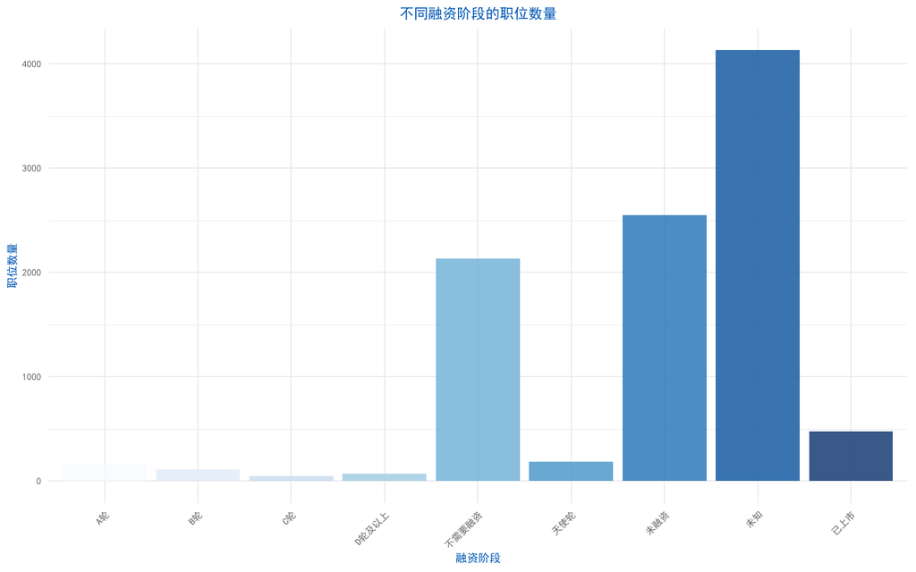

```r
# 计算融资阶段分布
finance_summary <- data_log %>%
  group_by(融资阶段) %>%
  summarise(职位数量 = n(), 平均年薪 = mean(log(年薪), na.rm = TRUE)) %>%
  arrange(match(融资阶段, c("无需融资", "未融资", "天使轮", "A轮", "B轮", "C轮", "D轮及以上", "已上市", "未知")))

# 绘制柱状图
p_finance_bar <- ggplot(finance_summary, aes(x = 融资阶段, y = 职位数量, fill = 融资阶段)) +
  geom_bar(stat = "identity", alpha = 0.8) +
  labs(
    title = "不同融资阶段的职位数量",
    x = "融资阶段",
    y = "职位数量"
  ) +
  theme_minimal() +
  theme(
    text = element_text(family = theme_font),
    plot.title = element_text(size = 18, hjust = 0.5, face = "bold", color = "#0056b3"),
    axis.title.x = element_text(size = 14, face = "bold", color = "#0056b3"),
    axis.title.y = element_text(size = 14, face = "bold", color = "#0056b3"),
    axis.text.x = element_text(size = 12, angle = 45, hjust = 1, color = "#666666"),
    axis.text.y = element_text(size = 12, color = "#666666"),
    legend.position = "none"
  ) +
  scale_fill_brewer(palette = "Blues")

print(p_finance_bar)
```

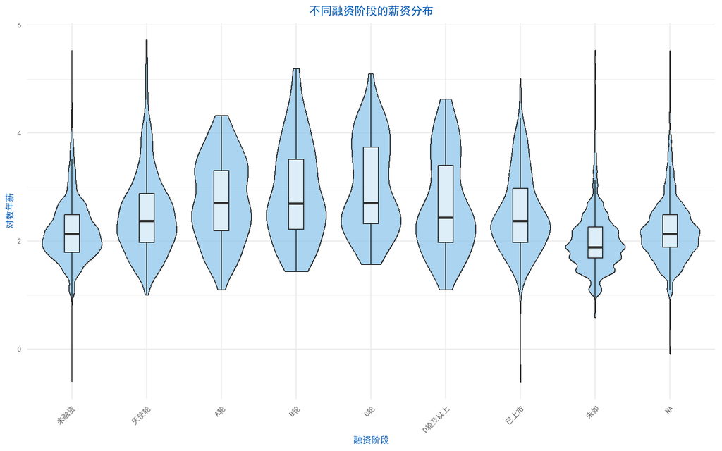

```r
# 小提琴图 + 箱线图（融资阶段）
p_finance_combined <- ggplot(data_log, aes(x = factor(融资阶段, levels = c("无需融资", "未融资", "天使轮", "A轮", "B轮", "C轮", "D轮及以上", "已上市", "未知")), y = log(年薪))) +
  geom_violin(fill = "#85C1E9", alpha = 0.7, width = 0.8, scale = "width") + # 小提琴图
  geom_boxplot(width = 0.2, fill = "white", alpha = 0.6, outlier.shape = NA) + # 箱线图

  labs(
    title = "不同融资阶段的薪资分布",
    x = "融资阶段",
    y = "对数年薪"
  ) +
  theme_minimal() +
  theme(
    text = element_text(family = theme_font),
    plot.title = element_text(size = 18, hjust = 0.5, face = "bold", color = "#0056b3"),
    axis.title.x = element_text(size = 14, face = "bold", color = "#0056b3"),
    axis.title.y = element_text(size = 14, face = "bold", color = "#0056b3"),
    axis.text.x = element_text(size = 12, angle = 45, hjust = 1, color = "#666666"),
    axis.text.y = element_text(size = 12, color = "#666666")
  )

print(p_finance_combined)
```

```r
# 描述性统计
scale_summary <- data_log %>%
  group_by(公司行业) %>%
  summarise(
    职位数量 = n(),
    平均年薪 = mean(年薪, na.rm = TRUE),
    中位年薪 = median(年薪, na.rm = TRUE)
  ) %>%
  arrange(desc(职位数量))

print(scale_summary)
```

```
## # A tibble: 14 × 4
##    公司行业             职位数量 平均年薪 中位年薪
##    <chr>                   <int>    <dbl>    <dbl>
##  1 互联网/IT/电子/通信      2495    15.4       9
##  2 房地产/建筑              1096     9.31      7.8
##  3 交通/物流/贸易/零售       999     9.28      7.8
##  4 服务业                    880     7.36      6
##  5 广告/传媒/文化/体育       817     9.91      7.8
##  6 专业服务                  575    12.5       9
##  7 机械/制造                 468    11.2       8.1
##  8 教育培训                  421     8.63      6.6
##  9 制药/医疗                 415     9.79      7.8
## 10 汽车                      415    10.3       7.8
## 11 消费品                    389    10.0       7.2
## 12 政府/非盈利机构/其他      362     8.50      6.6
## 13 金融                      287    15.4      10.8
## 14 能源/化工/环保            246    12.6       9
```

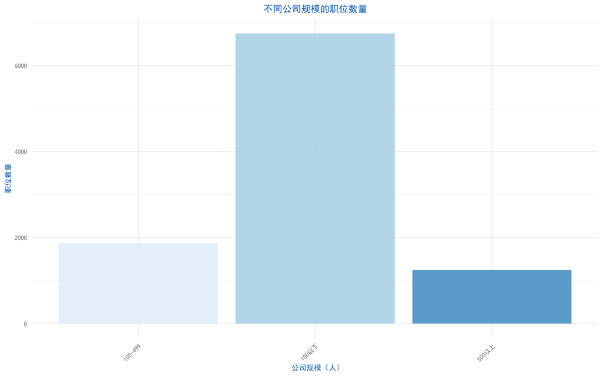

```r
# 计算公司规模分布
scale_summary <- data_log %>%
  group_by(公司规模) %>%
  summarise(职位数量 = n(), 平均年薪 = mean(log(年薪), na.rm = TRUE)) %>%
  arrange(match(公司规模, c("100以下", "100-499", "500以上")))

# 绘制柱状图
p_scale_bar <- ggplot(scale_summary, aes(x = 公司规模, y = 职位数量, fill = 公司规模)) +
  geom_bar(stat = "identity", alpha = 0.8) +
  labs(
    title = "不同公司规模的职位数量",
    x = "公司规模（人）",
    y = "职位数量"
  ) +
  theme_minimal() +
  theme(
    text = element_text(family = theme_font),
    plot.title = element_text(size = 18, hjust = 0.5, face = "bold", color = "#0056b3"),
    axis.title.x = element_text(size = 14, face = "bold", color = "#0056b3"),
    axis.title.y = element_text(size = 14, face = "bold", color = "#0056b3"),
    axis.text.x = element_text(size = 12, angle = 45, hjust = 1, color = "#666666"),
    axis.text.y = element_text(size = 12, color = "#666666"),
    legend.position = "none"
  ) +
  scale_fill_brewer(palette = "Blues")

print(p_scale_bar)
```

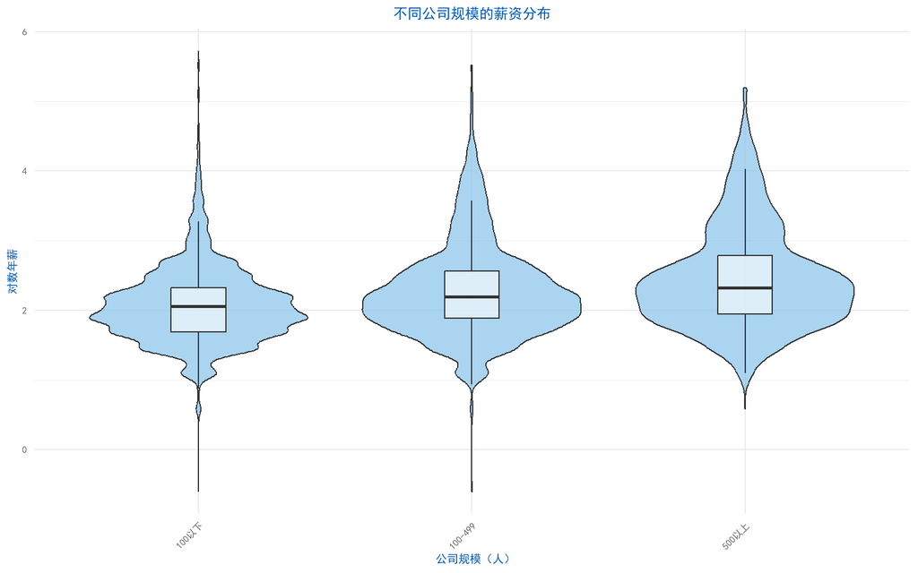

```r
# 小提琴图 + 箱线图（公司规模）
p_scale_combined <- ggplot(data_log, aes(x = factor(公司规模, levels = c("100以下", "100-499", "500以上")), y = log(年薪))) +
  geom_violin(fill = "#85C1E9", alpha = 0.7, width = 0.8, scale = "width") + # 小提琴图
  geom_boxplot(width = 0.2, fill = "white", alpha = 0.6, outlier.shape = NA) + # 箱线图
  labs(
    title = "不同公司规模的薪资分布",
    x = "公司规模（人）",
    y = "对数年薪"
  ) +
  theme_minimal() +
  theme(
    text = element_text(family = theme_font),
    plot.title = element_text(size = 18, hjust = 0.5, face = "bold", color = "#0056b3"),
    axis.title.x = element_text(size = 14, face = "bold", color = "#0056b3"),
    axis.title.y = element_text(size = 14, face = "bold", color = "#0056b3"),
    axis.text.x = element_text(size = 12, angle = 45, hjust = 1, color = "#666666"),
    axis.text.y = element_text(size = 12, color = "#666666")
  )

print(p_scale_combined)
```

```r
# 描述性统计
job_category_summary <- data_log %>%
  group_by(职业类别) %>%
  summarise(
    职位数量 = n(),
    平均年薪 = mean(年薪, na.rm = TRUE),
    中位年薪 = median(年薪, na.rm = TRUE)
  ) %>%
  arrange(desc(职位数量))

print(job_category_summary)
```

```
## # A tibble: 8 × 4
##   职业类别     职位数量 平均年薪 中位年薪
##   <chr>           <int>    <dbl>    <dbl>
## 1 其他职业类       1404     7.49     6.6
## 2 商务与管理类     1389    17.9      9
## 3 媒体与创意类     1372     8.73     7.25
## 4 技术与工程类     1356    18.2     13.4
## 5 法务与咨询类     1342    10.7      8.72
## 6 销售与市场类     1339     8.68     7.2
## 7 服务与支持类     1197     7.17     5.4
## 8 教育与培训类      466     9.87     9
```

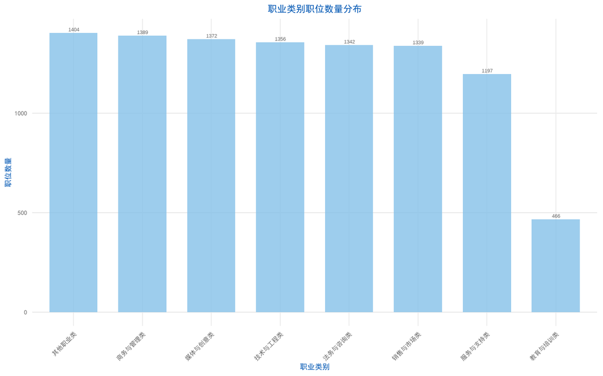

```r
# 绘制职业类别的柱状图
p_category_bar <- ggplot(job_category_summary, aes(x = reorder(职业类别, -职位数量), y = 职位数量)) +
  geom_bar(stat = "identity", fill = "#85C1E9", alpha = 0.8, width = 0.7) +
  geom_text(aes(label = 职位数量), vjust = -0.5, size = 3.5, color = "#666666") +
  labs(
    title = "职业类别职位数量分布",
    x = "职业类别",
    y = "职位数量"
  ) +
  theme_minimal() +
  theme(
    text = element_text(family = theme_font),
    plot.title = element_text(size = 18, hjust = 0.5, face = "bold", color = "#0056b3"),
    axis.title.x = element_text(size = 14, face = "bold", color = "#0056b3"),
    axis.title.y = element_text(size = 14, face = "bold", color = "#0056b3"),
    axis.text.x = element_text(size = 12, angle = 45, hjust = 1, color = "#666666"),
    axis.text.y = element_text(size = 12, color = "#666666"),
    panel.grid.major.y = element_line(color = "#E6E6E6"),
    panel.grid.minor = element_blank()
  )

print(p_category_bar)
```

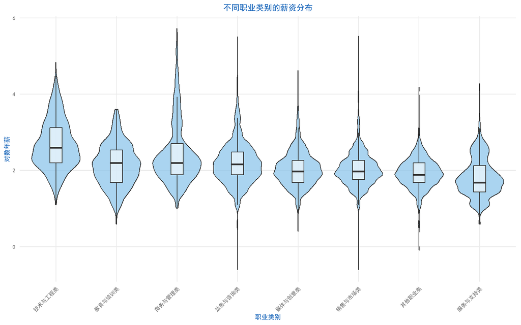

```r
# 小提琴图 + 箱线图（职业类别）
p_category_combined <- ggplot(data_log, aes(x = reorder(职业类别, -log_salary, FUN = median), y = log_salary)) +
  geom_violin(fill = "#85C1E9", alpha = 0.7, width = 0.8, scale = "width") + # 小提琴图
  geom_boxplot(width = 0.2, fill = "white", alpha = 0.6, outlier.shape = NA) + # 箱线图
  labs(
    title = "不同职业类别的薪资分布",
    x = "职业类别",
    y = "对数年薪"
  ) +
  theme_minimal() +
  theme(
    text = element_text(family = theme_font),
    plot.title = element_text(size = 18, hjust = 0.5, face = "bold", color = "#0056b3"),
    axis.title.x = element_text(size = 14, face = "bold", color = "#0056b3"),
    axis.title.y = element_text(size = 14, face = "bold", color = "#0056b3"),
    axis.text.x = element_text(size = 12, angle = 45, hjust = 1, color = "#666666"),
    axis.text.y = element_text(size = 12, color = "#666666"),
    panel.grid.major.y = element_line(color = "#E6E6E6"),
    panel.grid.minor = element_blank()
  )

print(p_category_combined)
```